# Marty’s weight

## Results

The above parameters were fixed as *k = 13* and *d = 9*. The resulting model is good for prediction as per the optimization of the parameters done before and it seems to decently capture the observed dynamics through the years.

It is my experience that when modelling a time series with a spline especially with not-missing at random data the ‘real’ concern is information overload for the observer, as in a model with fewer knots capture the underlying tendencies with less precision but may be better interpreted for some stakeholders.

In this example observations were made more often when I was motivated to modulate (lose) weight and this stark deviation from random made this example fun for me.

The underlying problem stated another way is how to handle periods of extremely sparse information.

Placing knots at regular intervals as denoted by the available information seems like a natural move.

I’m certain that for someone with different habits concerning weight data collection, these hyperparameters (k, d) would be different and should be revisited if my habits regarding their collection change significantly.

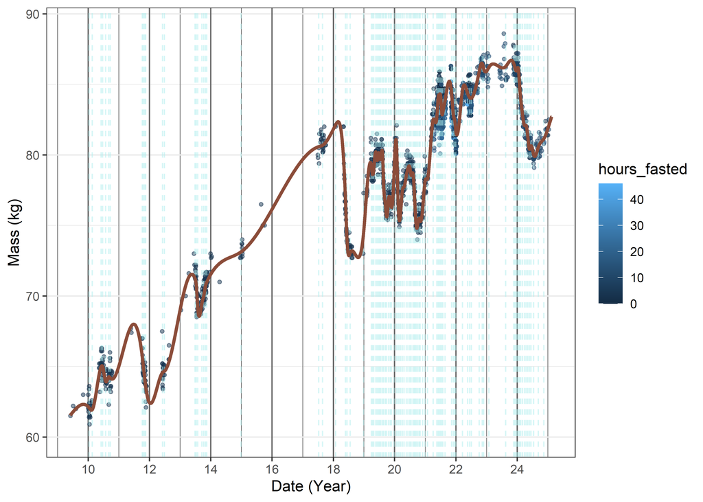

```r
library(readxl)
library(splines)
library(ggplot2)
library(dplyr)
library(lubridate)

setwd(here::here())

#####

k <- 13
days_before_last <- 9

#####
dat <- here::here("inst","extdata","martysweight.xlsx") %>%
  read_excel( col_types = c("date", "numeric", "numeric",
                            "numeric", "numeric", "numeric","numeric")) %>%
  filter(is.na(Mass) == FALSE) %>%
  mutate( Time_hours = ifelse( is.na(Time_hours)== TRUE, 12, Time_hours),
          Time_minutes = ifelse( is.na(Time_minutes)== TRUE, 0, Time_minutes),
          Time_fasted_hours = ifelse( is.na(Time_fasted_hours)== TRUE,
                                      4, Time_fasted_hours),
          Time_fasted_minutes = ifelse( is.na(Time_fasted_minutes)== TRUE,
                                        0, Time_fasted_minutes),
          numd = as.numeric( Date
                             + Time_hours * 3600
                             + Time_minutes * 60
                             - min(Date)) / 24,
          fastd = Time_fasted_hours + Time_fasted_minutes / 60,
          fastd_truncated = ifelse( fastd > 16, 16, fastd),
          maxinlast = 0
  )   %>%
  arrange(., numd)

##########
# Episodes setup

# Assuming 'dat' is your data frame
dat <- dat %>%
  mutate(
    fast_start =  round((numd - fastd /24)*7
                        , digits = 1)/7,
    fast_diff =  fast_start - lag(fast_start)

  )

##########

days_unique <- unique(floor(dat$numd))
days_as_knots <- seq(k,length(days_unique),by= k)
days_before_last_act <- length(days_unique) - dplyr::last(days_as_knots)
days_before_diff <- days_before_last_act - days_before_last
days_as_knots_corr <- days_as_knots + days_before_diff
days_as_knots_corr <-
  days_as_knots_corr[ days_as_knots_corr > 10 & # hard coded
                        days_as_knots_corr < length(days_unique)]

knot <- dat %>%
  filter(floor(numd) %in% days_unique[days_as_knots_corr]) %>%
  .$numd %>%
  floor %>%
  unique


expre <- paste(knot,collapse=",") %>%
  paste( "c(", ., ")") %>%
  paste("Mass ~ ns( fastd, df = 1) + ns(numd, knots =", ., ")"
  ) %>%
  as.formula(.)

mod <- lm( expre,
            control =  lmeControl(maxIter = 2000,
                                  msMaxIter = 3000,
                                  niterEM = 400,
                                  msVerbose = FALSE,
                                  tolerance = 1e-6,
                                  msTol = 1e-6),
            data = dat)


dat_p <- expand.grid( fastd = c(8),
                      numd = seq(1,max(dat$numd)+30,.1),
                      maxinlast = 12
                      ) %>%
  mutate( fastd_truncated = fastd)
dat_p$pred <- predict(mod, newdata = dat_p, level = 0)

dat_p$numd <- as.Date( dat_p$numd, origin = min(dat$Date))
dat$Date2  <- as.Date( dat$numd,   origin = min(dat$Date))

dat_p %>%
  filter(fastd==8) %>%
  mutate(hours_fasted = fastd) %>%
  ggplot(aes(x=numd, y = pred, color = hours_fasted)) +
    theme_bw() +
    theme(panel.grid.major.x = element_line(colour = "grey40"),
          panel.grid.minor.x = element_line(colour = "grey40")) +
    geom_point(data = dat,
               aes(x = Date2, y = Mass,
                   color=fastd, group = Episode)
               , size = 1, alpha = .5) +
    scale_y_continuous(limits = c(60,89)) +
    geom_vline(xintercept = days(floor(knot)) + min(dat$Date2), alpha = .5,
               color = "#AEEEEE", linetype = "dashed") +
    geom_line(linewidth=1.1, color = "salmon4") +
    scale_x_date(date_breaks = "2 years",date_minor_breaks = "1 year", date_labels = "%y") +
    labs( x = "Date (Year)",
          y = "Mass (kg)")
```

Trying out the model’s predictive powers, here is the projection for the next 30 days. Per the natural spline’s definition, it should be linear. While the knot placement was optimized for predicting this interval, but it should be kept in mind that changing ‘behavior’ mid-period (eg. starting/giving up a diet 2 weeks after the last observation) should seriously impact the results.

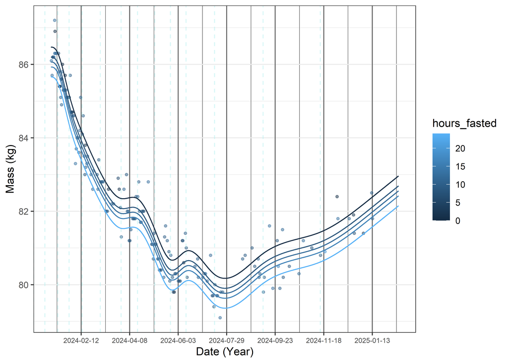

```r
dat_p <- expand.grid( fastd = c(0,8,12,16,24),
                      numd = seq(5332,#max(dat$numd)-60, # start of sema
                                 max(dat$numd)+30,.1),
                      maxinlast = 8
                      ) %>%
  mutate( fastd_truncated = fastd)

dat_p$pred <- predict(mod, newdata = dat_p, level = 0)

dat_p$numd <- as.Date( dat_p$numd, origin = min(dat$Date))
dat$Date2  <- as.Date( dat$numd,   origin = min(dat$Date))

dat_p %>%
  mutate(hours_fasted = fastd) %>%
  ggplot(aes(x=numd, y = pred, color = hours_fasted)) +
    theme_bw() +
    theme(panel.grid.major.x = element_line(colour = "grey40"),
          panel.grid.minor.x = element_line(colour = "grey40"),
          # smaller x axis text
          axis.text.x = element_text(size = 7)
          ) +
    geom_point(data = dat %>% filter(numd>5332), #max(numd)- 60),
               aes(x = Date2, y = Mass,
                   color=fastd, group = Episode)
               , size = 1, alpha = .5) +
    #scale_y_continuous(limits = c(60,89)) +
    geom_vline(xintercept = days(floor(knot)) + min(dat$Date2), alpha = .5,
               color = "#AEEEEE", linetype = "dashed") +
    geom_line(mapping = aes(group = factor(fastd)), linewidth=0.5) +
    scale_x_date(date_breaks = "8 weeks",date_minor_breaks = "4 weeks"
                 #, date_labels = "%y"
                 ) +
    labs( x = "Date (Year)",
          y = "Mass (kg)")
```

## Diagnostics

This section is only interesting if you are interested in the model fit, and how correct some of the model’s base assumption may be.

Model diagnostics are acceptable (to me) which is great news. Autocorrelation is high unfortunately, but perhaps in light of the hyperparameter optimization with rolling forecasts, this may be excused.

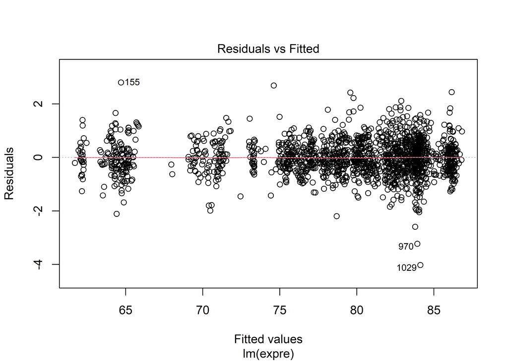

```r
plot(mod, 1)
```

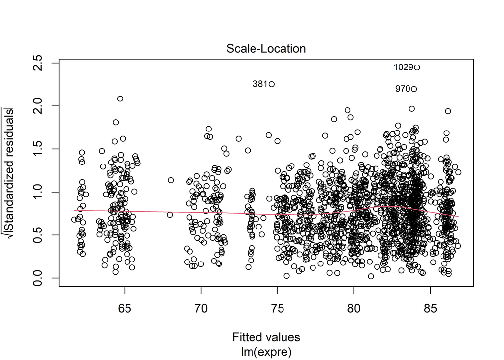

```r
plot(mod, 3)
```

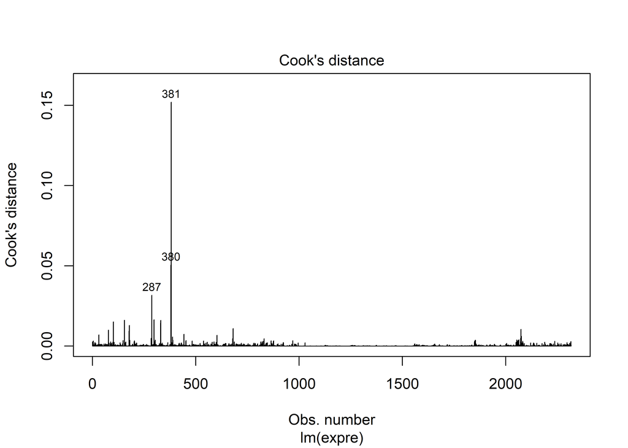

```r
plot(mod, 4)
```

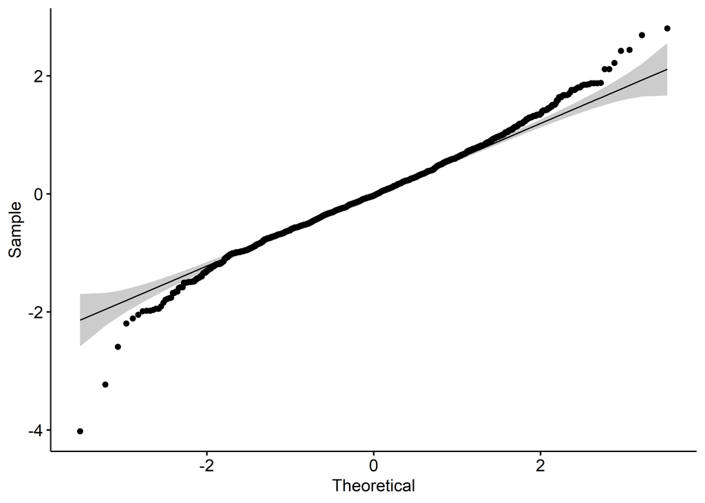

```r
ggpubr::ggqqplot(residuals(mod))
```

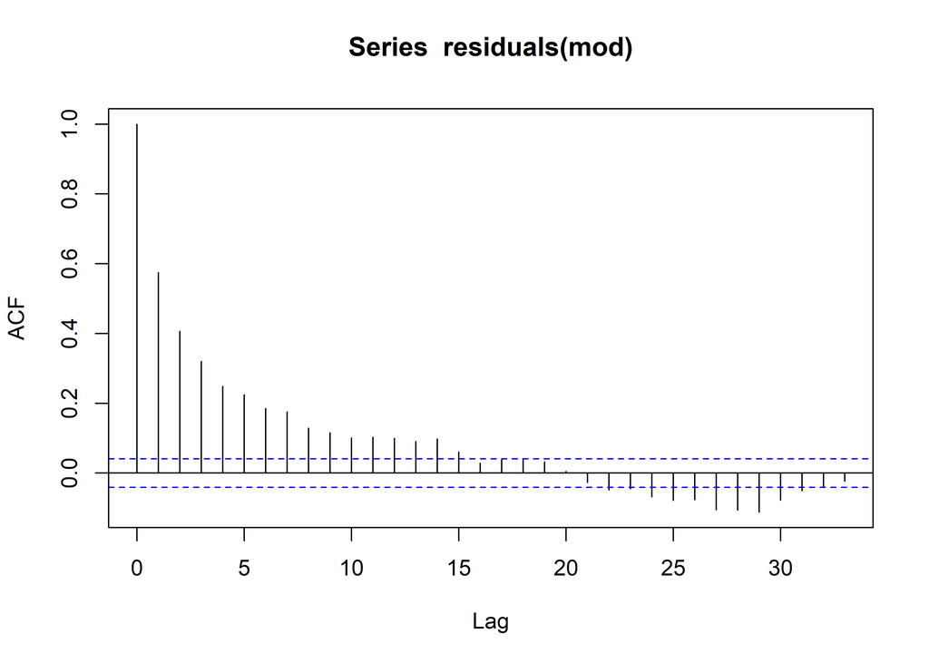

```r
plot(acf(residuals(mod)))
```